# Time series I: EDA

Radu Ioan-Alexandru (Gr 405) Stefan Eva (Gr 405)

```
 16 decembrie 2018
```

## Structure

**1. Defining a `ts` object**

*a) using the **ts** function*

**2. Time plots**

**3. Time series patterns**

*3.1 Trend:*

*3.2 Seasonal:*

*3.3 Cyclic:*

**4.Seasonal plots**

**5.Seasonal subseries plots**

**6. Scatterplots**

*6.1. Correlation*

*6.2. Scatterplot matrices*

**7. Lag plots**

**8. Autocorellation**

*8.1. Trend and seasonality in ACF plots*

**9. White noise**

**10. Some simple forecasting methods**

*10.1. Average method*

*10.2. Naive method*

*10.3. Seasonal naive method*

*10.4. Drift method*

*10.5. Examples*

**11. Transformations and adjustments**

*11.1 Calendar adjustments*

*11.2 Population adjustments*

*11.3 Inflation adjustments*

*11.4 Mathematical transformations*

**12. Residual diagnostics**

*12.1 Fitted values*

*12.2 Residuals*

*12.3 Example: Forecasting the Google daily closing stock price*

**13. Evaluating forecast accuracy**

*13.1 Pipe operator*

*13.2 Example: using tsCV()*

**14. Prediction intervals**

*14.1 Benchmark methods*

*14.2 Prediction intervals from bootstrapped residuals*

*14.5 Prediction intervals with transformations*

**15. The forecast package in R**

*15.1 Functions that output a forecast object:*

*15.2 `forecast()` function*

## 10. Some simple forecasting methods

#### Some forecasting methods are extremely simple and surprisingly effective.

1. **Average method**
2. **Naïve method**
3. **Seasonal naïve method**
4. **Drift method**

## **10.1. Average method**

#### Here, the forecasts of all future values are equal to the average (or “mean”) of the historical data. If we let the historical data be denoted by $y_{1},\dots,y_{T}$, then we can write the forecasts as

$\hat{y}_{T+h|T} = \bar{y} = (y_{1}+\dots+y_{T})/T.$

#### The notation $\hat{y}_{T+h|T}$ is a short-hand for the estimate of $y_{T+h}$ based on the data $y_1,\dots,y_T$.

```r
y <- ts(c(123,39,78,52,110), start=2012) # y contains the time series
h = 10 # h is the forecast horizon
meanf(y, h)
```

```
##      Point Forecast    Lo 80    Hi 80     Lo 95   Hi 95
## 2017           80.4 19.74314 141.0569 -29.44201 190.242
## 2018           80.4 19.74314 141.0569 -29.44201 190.242
## 2019           80.4 19.74314 141.0569 -29.44201 190.242
## 2020           80.4 19.74314 141.0569 -29.44201 190.242
## 2021           80.4 19.74314 141.0569 -29.44201 190.242
## 2022           80.4 19.74314 141.0569 -29.44201 190.242
## 2023           80.4 19.74314 141.0569 -29.44201 190.242
## 2024           80.4 19.74314 141.0569 -29.44201 190.242
## 2025           80.4 19.74314 141.0569 -29.44201 190.242
## 2026           80.4 19.74314 141.0569 -29.44201 190.242
```

## **10.2. Naïve method**

#### For naïve forecasts, we simply set all forecasts to be the value of the last observation. That is,

$\hat{y}_{T+h|T} = y_{T}.$

#### This method works remarkably well for many economic and financial time series.

```r
y <- ts(c(123,39,78,52,110), start=2012) # y contains the time series
h = 10 # h is the forecast horizon
naive(y, h)
```

```
##      Point Forecast       Lo 80    Hi 80         Lo 95    Hi 95
## 2017            110   38.024548 181.9755   -0.07695497 220.0770
## 2018            110    8.211339 211.7887  -45.67232262 265.6723
## 2019            110  -14.665140 234.6651  -80.65887874 300.6589
## 2020            110  -33.950904 253.9509 -110.15390993 330.1539
## 2021            110  -50.942004 270.9420 -136.13955406 356.1396
## 2022            110  -66.303132 286.3031 -159.63237211 379.6324
## 2023            110  -80.429147 300.4291 -181.23624792 401.2362
## 2024            110  -93.577321 313.5773 -201.34464524 421.3446
## 2025            110 -105.926356 325.9264 -220.23086490 440.2309
## 2026            110 -117.606364 337.6064 -238.09389559 458.0939
```

```r
rwf(y, h) # Equivalent alternative
```

```
##      Point Forecast       Lo 80    Hi 80         Lo 95    Hi 95
## 2017            110   38.024548 181.9755   -0.07695497 220.0770
## 2018            110    8.211339 211.7887  -45.67232262 265.6723
## 2019            110  -14.665140 234.6651  -80.65887874 300.6589
## 2020            110  -33.950904 253.9509 -110.15390993 330.1539
## 2021            110  -50.942004 270.9420 -136.13955406 356.1396
## 2022            110  -66.303132 286.3031 -159.63237211 379.6324
## 2023            110  -80.429147 300.4291 -181.23624792 401.2362
## 2024            110  -93.577321 313.5773 -201.34464524 421.3446
## 2025            110 -105.926356 325.9264 -220.23086490 440.2309
## 2026            110 -117.606364 337.6064 -238.09389559 458.0939
```

#### Because a naïve forecast is optimal when data follow a random walk (see Section 8.1), these are also called random **walk forecasts.**

## **10.3. Seasonal naïve method**

#### A similar method is useful for highly seasona l data. In this case, we set each forecast to be equal to the last observed value from the same season of the year (e.g., the same month of the previous year). Formally, the forecast for time $T+h$ is written as

$\hat{y}_{T+h|T} = y_{T+h-m(k+1)},$

#### where $m=$ the seasonal period, and $k$ is the integer part of $(h−1)/m$ (i.e., the number of complete years in the forecast period prior to time $T+h$). This looks more complicated than it really is. For example, with monthly data, the forecast for all future February values is equal to the last observed February value. With quarterly data, the forecast of all future Q2 values is equal to the last observed Q2 value (where Q2 means the second quarter). Similar rules apply for other months and quarters, and for other seasonal periods.

```r
y <- ts(c(123,39,78,52,110), start=2012) # y contains the time series
h = 10 # h is the forecast horizon
snaive(y, h)
```

```
##      Point Forecast       Lo 80    Hi 80         Lo 95    Hi 95
## 2017            110   38.024548 181.9755   -0.07695497 220.0770
## 2018            110    8.211339 211.7887  -45.67232262 265.6723
## 2019            110  -14.665140 234.6651  -80.65887874 300.6589
## 2020            110  -33.950904 253.9509 -110.15390993 330.1539
## 2021            110  -50.942004 270.9420 -136.13955406 356.1396
## 2022            110  -66.303132 286.3031 -159.63237211 379.6324
## 2023            110  -80.429147 300.4291 -181.23624792 401.2362
## 2024            110  -93.577321 313.5773 -201.34464524 421.3446
## 2025            110 -105.926356 325.9264 -220.23086490 440.2309
## 2026            110 -117.606364 337.6064 -238.09389559 458.0939
```

## **10.4. Drift method**

#### A variation on the naïve method is to allow the forecasts to increase or decrease over time, where the amount of change over time (called the **drift**) is set to be the average change seen in the historical data. Thus the forecast for time $T+h$ is given by

$\hat{y}_{T+h|T} = y_{T} + \frac{h}{T-1}\sum_{t=2}^T (y_{t}-y_{t-1}) = y_{T} + h \left( \frac{y_{T} -y_{1}}{T-1}\right).$

#### This is equivalent to drawing a line between the first and last observations, and extrapolating it into the future.

```r
y <- ts(c(123,39,78,52,110), start=2012) # y contains the time series
h = 10 # h is the forecast horizon
rwf(y, h, drift=TRUE)
```

```
##      Point Forecast      Lo 80    Hi 80      Lo 95    Hi 95
## 2017         106.75   16.33441 197.1656  -31.52871 245.0287
## 2018         103.50  -34.09215 241.0922 -106.92904 313.9290
## 2019         100.25  -79.38814 279.8881 -174.48283 374.9828
## 2020          97.00 -122.52168 316.5217 -238.72944 432.7294
## 2021          93.75 -164.49662 351.9966 -301.20412 488.7041
## 2022          90.50 -205.76762 386.7676 -362.60223 543.6022
## 2023          87.25 -246.57531 421.0753 -423.29175 597.7917
## 2024          84.00 -287.06038 455.0604 -483.48788 651.4879
## 2025          80.75 -327.31118 488.8112 -543.32571 704.8257
## 2026          77.50 -367.38614 522.3861 -602.89464 757.8946
```

## Examples

#### The Figure bellow shows the first three methods applied to the quarterly beer production data.

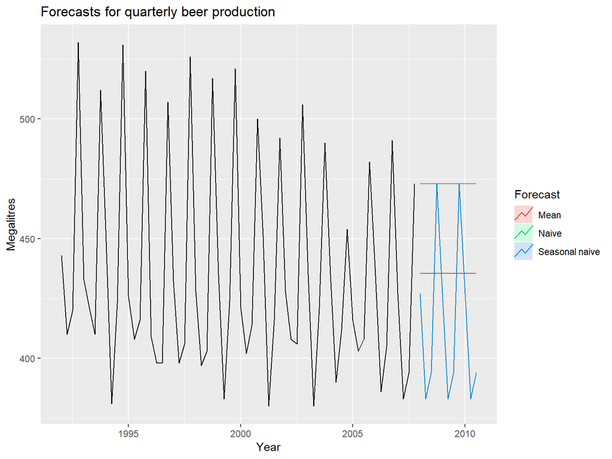

```r
# Set training data from 1992 to 2007
beer2 <- window(ausbeer,start=1992,end=c(2007,4))
# Plot some forecasts
autoplot(beer2) +
  autolayer(meanf(beer2, h=11),
    series="Mean", PI=FALSE) +
  autolayer(naive(beer2, h=11),
    series="Naïve", PI=FALSE) +
  autolayer(snaive(beer2, h=11),
    series="Seasonal naïve", PI=FALSE) +
  ggtitle("Forecasts for quarterly beer production") +
  xlab("Year") + ylab("Megalitres") +
  guides(colour=guide_legend(title="Forecast"))
```

#### The Figure bellow, the non-seasonal methods are applied to a series of 200 days of the Google daily closing stock price.

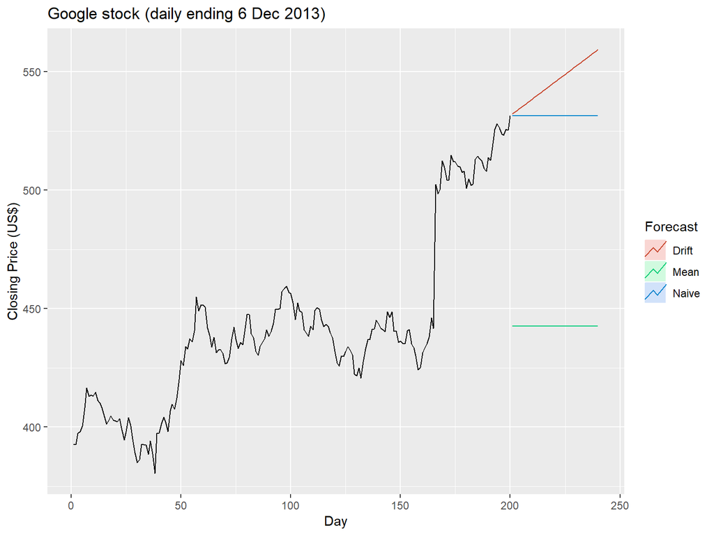

```r
autoplot(goog200) +
  autolayer(meanf(goog200, h=40),
    series="Mean", PI=FALSE) +
  autolayer(rwf(goog200, h=40),
    series="Naïve", PI=FALSE) +
  autolayer(rwf(goog200, drift=TRUE, h=40),
    series="Drift", PI=FALSE) +
  ggtitle("Google stock (daily ending 6 Dec 2013)") +
  xlab("Day") + ylab("Closing Price (US$)") +
  guides(colour=guide_legend(title="Forecast"))
```

#### Sometimes one of these simple methods will be the best forecasting method available; but in many cases, these methods will serve as benchmarks rather than the method of choice. That is, any forecasting methods we develop will be compared to these simple methods to ensure that the new method is better than these simple alternatives. If not, the new method is not worth considering.

## 11. Transformations and adjustments

### **11.1 Calendar adjustments**

### Some of the variation seen in seasonal data may be due to simple calendar effects. In such cases, it is usually much easier to remove the variation before fitting a forecasting model. The `monthdays()` function will compute the number of days in each month or quarter.

### For example, if you are studying the monthly milk production on a farm, there will be variation between the months simply because of the different numbers of days in each month, in addition to the seasonal variation across the year.

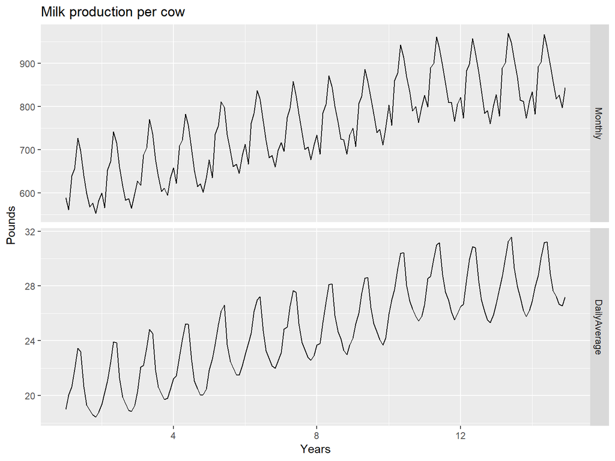

```r
dframe <- cbind(Monthly = milk,
                DailyAverage = milk/monthdays(milk))
  autoplot(dframe, facet=TRUE) +
    xlab("Years") + ylab("Pounds") +
    ggtitle("Milk production per cow")
```

### **11.2 Population adjustments**

#### Any data that are affected by population changes can be adjusted to give per-capita data. That is, consider the data per person (or per thousand people, or per million people) rather than the total. For example, if you are studying the number of hospital beds in a particular region over time, the results are much easier to interpret if you remove the effects of population changes by considering the number of beds per thousand people. Then you can see whether there have been real increases in the number of beds, or whether the increases are due entirely to population increases.

### **11.3 Inflation adjustments**

#### Data which are affected by the value of money are best adjusted before modelling. For example, the average cost of a new house will have increased over the last few decades due to inflation. A $200,000 house this year is not the same as a $200,000 house twenty years ago. For this reason, financial time series are usually adjusted so that all values are stated in dollar values from a particular year. For example, the house price data may be stated in year 2000 dollars.

### **11.4 Mathematical transformations**

#### A useful family of transformations, that includes both logarithms and power transformations, is the family of Box-Cox transformations, which depend on the parameter λ and are defined as follows:

$w_t = \begin{cases} \log(y_t) & \text{if $\lambda=0$}; \\ (y_t^\lambda-1)/\lambda & \text{otherwise}. \end{cases}$

#### The logarithm in a Box-Cox transformation is always a natural logarithm (i.e., to base e). So if λ=0, natural logarithms are used, but if λ≠0, a power transformation is used, followed by some simple scaling.

## 12. Residual diagnostics

### **12.1 Fitted values**

#### Each observation in a time series can be forecast using all previous observations. We call these **fitted values** and they are denoted by $\hat{y}_{t|t-1}$, meaning the forecast of $y_t$ based on observations $y_{1},\dots,y_{t-1}$. We use these so often, we sometimes drop part of the subscript and just write $\hat{y}_t$ instead of $\hat{y}_{t|t-1}$. Fitted values always involve one-step forecasts.

### **12.2 Residuals**

#### The “residuals” in a time series model are what is left over after fitting a model. For many (but not all) time series models, the residuals are equal to the difference between the observations and the corresponding fitted values:

$e_{t} = y_{t}-\hat{y}_{t}.$

#### Residuals are useful in checking whether a model has adequately captured the information in the data. A good forecasting method will yield residuals with the following properties:

#### The residuals are uncorrelated. If there are correlations between residuals, then there is information left in the residuals which should be used in computing forecasts.

#### The residuals have zero mean. If the residuals have a mean other than zero, then the forecasts are biased.

### **12.3 Example: Forecasting the Google daily closing stock price**

#### For stock market prices and indexes, the best forecasting method is often the naïve method. That is, each forecast is simply equal to the last observed value, or $\hat{y}_{t} = y_{t-1}$. Hence, the residuals are simply equal to the difference between consecutive observations:

$e_{t} = y_{t} - \hat{y}_{t} = y_{t} - y_{t-1}.$

#### The following graph shows the Google daily closing stock price (GOOG). The large jump at day 166 corresponds to 18 October 2013 when the price jumped 12% due to unexpectedly strong third quarter results.

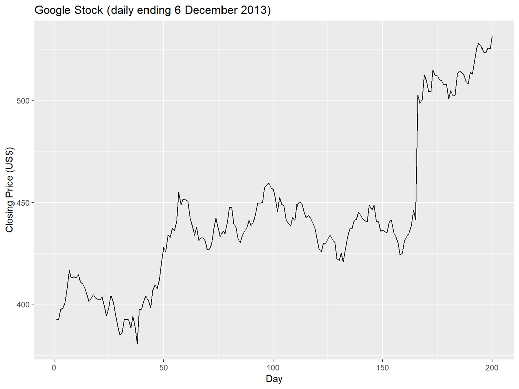

```r
autoplot(goog200) +
  xlab("Day") + ylab("Closing Price (US$)") +
  ggtitle("Google Stock (daily ending 6 December 2013)")
```

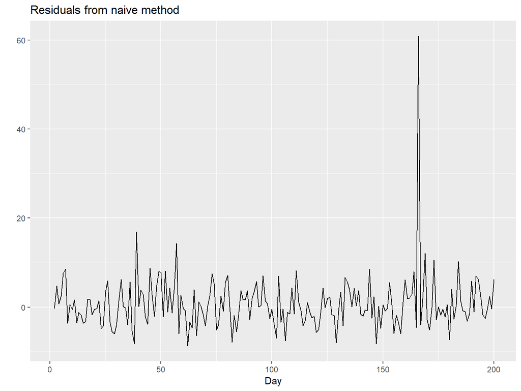

```r
res <- residuals(naive(goog200))
autoplot(res) + xlab("Day") + ylab("") +
  ggtitle("Residuals from naïve method")
```

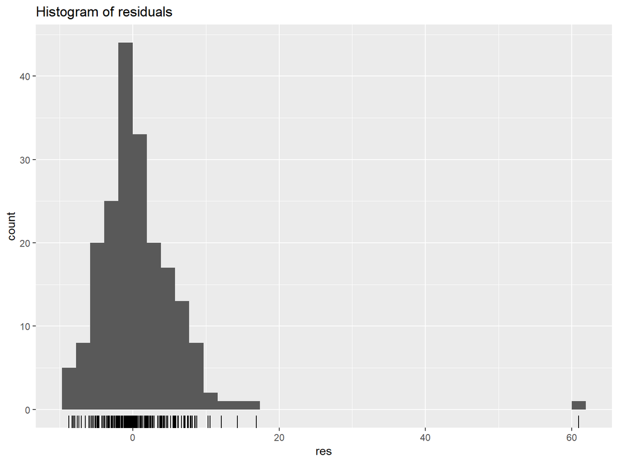

```r
gghistogram(res) + ggtitle("Histogram of residuals")
```

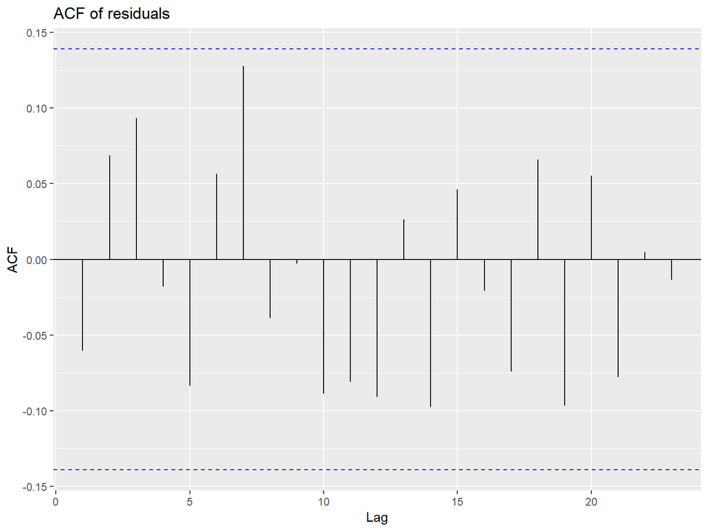

```r
ggAcf(res) + ggtitle("ACF of residuals")
```

#### These graphs show that the naïve method produces forecasts that appear to account for all available information. The mean of the residuals is close to zero and there is no significant correlation in the residuals series. The time plot of the residuals shows that the variation of the residuals stays much the same across the historical data, apart from the one outlier, and therefore the residual variance can be treated as constant. This can also be seen on the histogram of the residuals. The histogram suggests that the residuals may not be normal — the right tail seems a little too long, even when we ignore the outlier. Consequently, forecasts from this method will probably be quite good, but prediction intervals that are computed assuming a normal distribution may be inaccurate.

## 13. Evaluating forecast accuracy

### **13.1 Functions to subset a time series**

#### The `window()` function is useful when extracting a portion of a time series, such as we need when creating training and test sets. In the `window()` function, we specify the start and/or end of the portion of time series required using time values. For example,

```r
window(ausbeer, start=1995)
```

```
##      Qtr1 Qtr2 Qtr3 Qtr4
## 1995  426  408  416  520
## 1996  409  398  398  507
## 1997  432  398  406  526
## 1998  428  397  403  517
## 1999  435  383  424  521
## 2000  421  402  414  500
## 2001  451  380  416  492
## 2002  428  408  406  506
## 2003  435  380  421  490
## 2004  435  390  412  454
## 2005  416  403  408  482
## 2006  438  386  405  491
## 2007  427  383  394  473
## 2008  420  390  410  488
## 2009  415  398  419  488
## 2010  414  374
```

#### extracts all data from 1995 onward.

#### Another useful function is subset() which allows for more types of subsetting. A great advantage of this function is that it allows the use of indices to choose a subset. For example,

```r
subset(ausbeer, start=length(ausbeer)-4*5)
```

```
##      Qtr1 Qtr2 Qtr3 Qtr4
## 2005       403  408  482
## 2006  438  386  405  491
## 2007  427  383  394  473
## 2008  420  390  410  488
## 2009  415  398  419  488
## 2010  414  374
```

#### extracts the last 5 years of observations from `ausbeer`. It also allows extracting all values for a specific season. For example,

```r
subset(ausbeer, quarter = 1)
```

```
## Time Series:
## Start = 1956
## End = 2010
## Frequency = 1
##  [1] 284 262 272 261 286 295 279 294 313 331 335 353 393 383 387 410 419
## [18] 458 465 500 510 486 515 503 513 548 493 475 453 464 459 481 474 467
## [35] 485 464 443 433 449 426 409 432 428 435 421 451 428 435 435 416 438
## [52] 427 420 415 414
```

#### extracts the first quarters for all years.

#### Finally, `head` and `tail` are useful for extracting the first few or last few observations. For example, the last 5 years of `ausbeer` can also be obtained using

```r
tail(ausbeer, 4*5)
```

```
##      Qtr1 Qtr2 Qtr3 Qtr4
## 2005            408  482
## 2006  438  386  405  491
## 2007  427  383  394  473
## 2008  420  390  410  488
## 2009  415  398  419  488
## 2010  414  374
```

## **Examples**

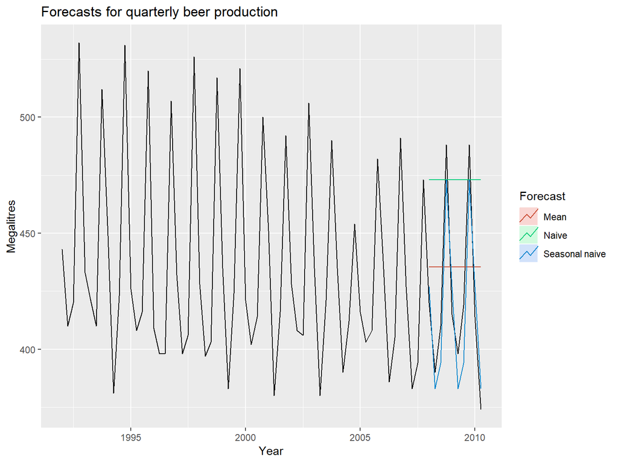

```r
beer2 <- window(ausbeer,start=1992,end=c(2007,4))
beerfit1 <- meanf(beer2,h=10)
beerfit2 <- rwf(beer2,h=10)
beerfit3 <- snaive(beer2,h=10)
autoplot(window(ausbeer, start=1992)) +
  autolayer(beerfit1, series="Mean", PI=FALSE) +
  autolayer(beerfit2, series="Naïve", PI=FALSE) +
  autolayer(beerfit3, series="Seasonal naïve", PI=FALSE) +
  xlab("Year") + ylab("Megalitres") +
  ggtitle("Forecasts for quarterly beer production") +
  guides(colour=guide_legend(title="Forecast"))
```

#### The figure above shows three forecast methods applied to the quarterly Australian beer production using data only to the end of 2007. The actual values for the period 2008–2010 are also shown. We compute the forecast accuracy measures for this period.

```r
beer3 <- window(ausbeer, start=2008)
accuracy(beerfit1, beer3)
```

```
##                   ME     RMSE      MAE        MPE     MAPE     MASE
## Training set   0.000 43.62858 35.23438 -0.9365102 7.886776 2.463942
## Test set     -13.775 38.44724 34.82500 -3.9698659 8.283390 2.435315
##                     ACF1 Theil's U
## Training set -0.10915105        NA
## Test set     -0.06905715  0.801254
```

```r
accuracy(beerfit2, beer3)
```

```
##                       ME     RMSE      MAE         MPE     MAPE     MASE
## Training set   0.4761905 65.31511 54.73016  -0.9162496 12.16415 3.827284
## Test set     -51.4000000 62.69290 57.40000 -12.9549160 14.18442 4.013986
##                     ACF1 Theil's U
## Training set -0.24098292        NA
## Test set     -0.06905715  1.254009
```

```r
accuracy(beerfit3, beer3)
```

```
##                     ME     RMSE  MAE        MPE     MAPE      MASE
## Training set -2.133333 16.78193 14.3 -0.5537713 3.313685 1.0000000
## Test set      5.200000 14.31084 13.4  1.1475536 3.168503 0.9370629
##                    ACF1 Theil's U
## Training set -0.2876333        NA
## Test set      0.1318407  0.298728
```

#### It is obvious from the graph that the seasonal naïve method is best for these data, although it can still be improved, as we will discover later. Sometimes, different accuracy measures will lead to different results as to which forecast method is best. However, in this case, all of the results point to the seasonal naïve method as the best of these three methods for this data set.

#### To take a non-seasonal example, consider the Google stock price. The following graph shows the 200 observations ending on 6 Dec 2013, along with forecasts of the next 40 days obtained from three different methods.

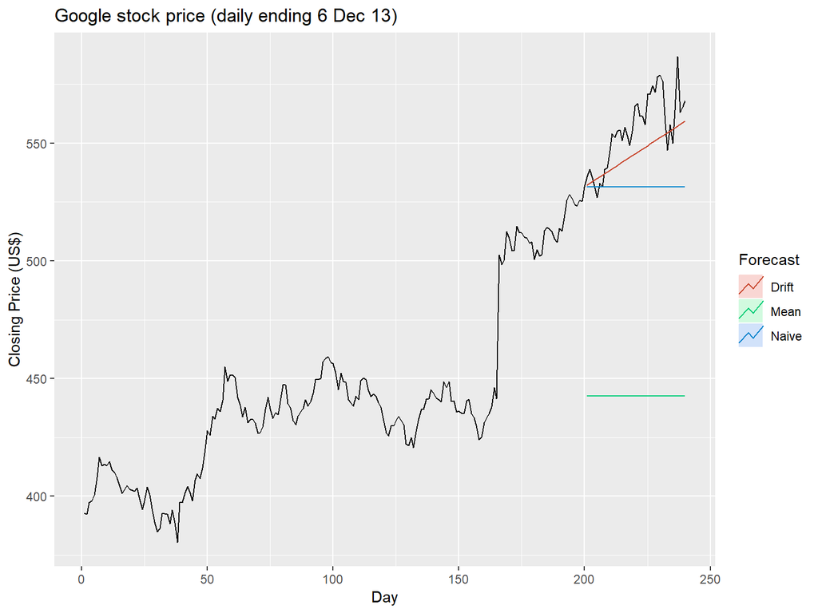

```r
googfc1 <- meanf(goog200, h=40)
googfc2 <- rwf(goog200, h=40)
googfc3 <- rwf(goog200, drift=TRUE, h=40)
autoplot(subset(goog, end = 240)) +
  autolayer(googfc1, PI=FALSE, series="Mean") +
  autolayer(googfc2, PI=FALSE, series="Naïve") +
  autolayer(googfc3, PI=FALSE, series="Drift") +
  xlab("Day") + ylab("Closing Price (US$)") +
  ggtitle("Google stock price (daily ending 6 Dec 13)") +
  guides(colour=guide_legend(title="Forecast"))
```

```r
googtest <- window(goog, start=201, end=240)
accuracy(googfc1, googtest)
```

```
##                         ME      RMSE       MAE        MPE     MAPE
## Training set -4.296286e-15  36.91961  26.86941 -0.6596884  5.95376
## Test set      1.132697e+02 114.21375 113.26971 20.3222979 20.32230
##                   MASE      ACF1 Theil's U
## Training set  7.182995 0.9668981        NA
## Test set     30.280376 0.8104340  13.92142
```

```r
accuracy(googfc2, googtest)
```

```
##                      ME      RMSE       MAE       MPE      MAPE     MASE
## Training set  0.6967249  6.208148  3.740697 0.1426616 0.8437137 1.000000
## Test set     24.3677328 28.434837 24.593517 4.3171356 4.3599811 6.574582
##                     ACF1 Theil's U
## Training set -0.06038617        NA
## Test set      0.81043397  3.451903
```

```r
accuracy(googfc3, googtest)
```

```
##                        ME      RMSE       MAE         MPE      MAPE
## Training set 4.653165e-13  6.168928  3.824406 -0.01570676 0.8630093
## Test set     1.008487e+01 14.077291 11.667241  1.77566103 2.0700918
##                  MASE        ACF1 Theil's U
## Training set 1.022378 -0.06038617        NA
## Test set     3.119002  0.64732736  1.709275
```

#### Here, the best method is the drift method (regardless of which accuracy measure is used).

## 13. Evaluating forecast accuracy (cont’d)

### **13.3 Pipe operator**

```r
goog200 %>% tsCV(forecastfunction=rwf, drift=TRUE, h=1) -> e
e^2 %>% mean(na.rm=TRUE) %>% sqrt()
```

```
## [1] 6.233245
```

```
#> [1] 6.233
```

```r
goog200 %>% rwf(drift=TRUE) %>% residuals() -> res
res^2 %>% mean(na.rm=TRUE) %>% sqrt()
```

```
## [1] 6.168928
```

```
#> [1] 6.169
```

#### The left hand side of each pipe is passed as the first argument to the function on the right hand side. This is consistent with the way we read from left to right in English. When using pipes, all other arguments must be named, which also helps readability. When using pipes, it is natural to use the right arrow assignment `->` rather than the left arrow. For example, the third line above can be read as “Take the `goog200` series, pass it to `rwf()` with `drift=TRUE`, compute the resulting residuals, and store them as `res`”.

#### We will use the pipe operator whenever it makes the code easier to read. In order to be consistent, we will always follow a function with parentheses to differentiate it from other objects, even if it has no arguments. See, for example, the use of `sqrt()` and `residuals()` in the code above.

## **13.4 Example: using tsCV()**

#### The `goog200` data includes daily closing stock price of Google Inc from the NASDAQ exchange for 200 consecutive trading days starting on 25 February 2013.

#### The code below evaluates the forecasting performance of 1- to 8-step-ahead naïve forecasts with `tsCV()`, using MSE as the forecast error measure. The plot shows that the forecast error increases as the forecast horizon increases, as we would expect.

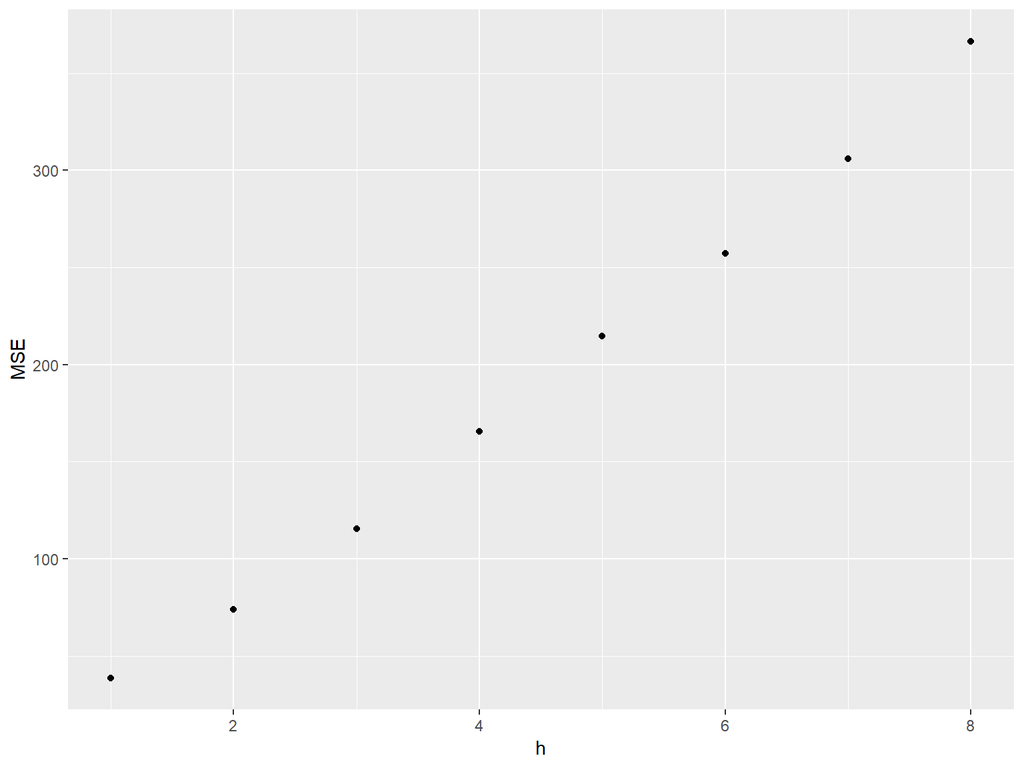

```r
e <- tsCV(goog200, forecastfunction=naive, h=8)
# Compute the MSE values and remove missing values
mse <- colMeans(e^2, na.rm = T)
# Plot the MSE values against the forecast horizon
data.frame(h = 1:8, MSE = mse) %>%
  ggplot(aes(x = h, y = MSE)) + geom_point()
```

## 14. Prediction intervals

### **14.1 Benchmark methods**

#### Prediction intervals will be computed for you when using any of the benchmark forecasting methods. For example, here is the output when using the naïve method for the Google stock price.

```r
naive(goog200)
```

```
##     Point Forecast    Lo 80    Hi 80    Lo 95    Hi 95
## 201       531.4783 523.5221 539.4344 519.3104 543.6461
## 202       531.4783 520.2266 542.7300 514.2703 548.6862
## 203       531.4783 517.6978 545.2587 510.4029 552.5536
## 204       531.4783 515.5660 547.3906 507.1425 555.8140
## 205       531.4783 513.6878 549.2687 504.2701 558.6865
## 206       531.4783 511.9898 550.9668 501.6732 561.2833
## 207       531.4783 510.4283 552.5282 499.2851 563.6714
## 208       531.4783 508.9749 553.9816 497.0623 565.8942
## 209       531.4783 507.6098 555.3467 494.9747 567.9819
## 210       531.4783 506.3187 556.6378 493.0001 569.9565
```

```
#>     Point Forecast Lo 80 Hi 80 Lo 95 Hi 95
#> 201          531.5 523.5 539.4 519.3 543.6
#> 202          531.5 520.2 542.7 514.3 548.7
#> 203          531.5 517.7 545.3 510.4 552.6
#> 204          531.5 515.6 547.4 507.1 555.8
#> 205          531.5 513.7 549.3 504.3 558.7
#> 206          531.5 512.0 551.0 501.7 561.3
#> 207          531.5 510.4 552.5 499.3 563.7
#> 208          531.5 509.0 554.0 497.1 565.9
#> 209          531.5 507.6 555.3 495.0 568.0
#> 210          531.5 506.3 556.6 493.0 570.0
```

#### When plotted, the prediction intervals are shown as shaded region, with the strength of colour indicating the probability associated with the interval.

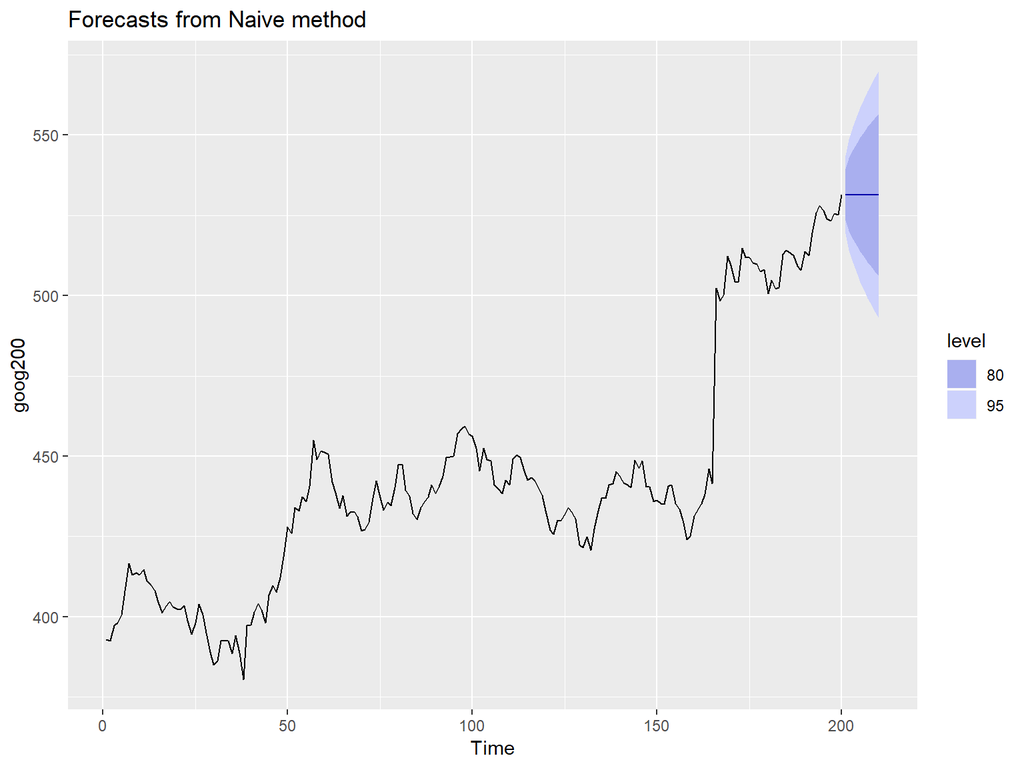

```r
autoplot(naive(goog200))
```

### **14.2 Prediction intervals from bootstrapped residuals**

#### To generate such intervals, we can simply add the bootstrap argument to our forecasting functions. For example:

```r
naive(goog200, bootstrap=TRUE)
```

```
##     Point Forecast    Lo 80    Hi 80    Lo 95    Hi 95
## 201       531.4783 525.7409 537.7577 522.8646 541.0612
## 202       531.4783 523.2528 539.3011 519.8413 545.3087
## 203       531.4783 521.2605 540.9718 517.0580 548.9173
## 204       531.4783 519.5457 542.8206 514.4866 553.6014
## 205       531.4783 517.7991 544.0307 512.3591 560.8042
## 206       531.4783 516.3967 545.4869 510.0396 575.6603
## 207       531.4783 514.7446 546.6118 507.8643 579.7801
## 208       531.4783 513.7991 547.9334 505.8275 582.1233
## 209       531.4783 512.4631 549.3181 504.7431 582.7136
## 210       531.4783 511.5132 550.8799 502.2155 584.2097
```

```
#>     Point Forecast Lo 80 Hi 80 Lo 95 Hi 95
#> 201          531.5 525.6 537.8 522.9 541.1
#> 202          531.5 523.0 539.4 519.5 546.2
#> 203          531.5 521.0 541.6 516.6 552.1
#> 204          531.5 519.4 543.4 514.1 566.7
#> 205          531.5 517.6 544.8 511.8 581.7
#> 206          531.5 516.2 546.8 509.8 583.4
#> 207          531.5 514.8 547.6 507.3 584.5
#> 208          531.5 513.2 549.5 505.8 587.7
#> 209          531.5 512.2 550.4 503.7 589.2
#> 210          531.5 510.7 551.7 502.1 591.3
```

#### In this case, they are similar (but not identical) to the prediction intervals based on the normal distribution.

## 15. The forecast package in R

### **15.1 `forecast()` function**

#### So far we have used functions which produce a `forecast` object directly.

#### The `forecast()` function works with many different types of inputs. It generally takes a time series or time series model as its main argument, and produces forecasts appropriately. It always returns objects of class `forecast`.

#### If the first argument is of class `ts`, it returns forecasts from the automatic ETS algorithm discussed in Chapter 7.

#### Here is a simple example, applying `forecast()` to the `ausbeer` data:

```r
forecast(ausbeer, h=4)
```

```
##         Point Forecast    Lo 80    Hi 80    Lo 95    Hi 95
## 2010 Q3       404.6025 385.8695 423.3355 375.9529 433.2521
## 2010 Q4       480.3982 457.5283 503.2682 445.4216 515.3748
## 2011 Q1       417.0367 396.5112 437.5622 385.6456 448.4277
## 2011 Q2       383.0996 363.5063 402.6930 353.1341 413.0651
```

```
#>         Point Forecast Lo 80 Hi 80 Lo 95 Hi 95
#> 2010 Q3          404.6 385.9 423.3 376.0 433.3
#> 2010 Q4          480.4 457.5 503.3 445.4 515.4
#> 2011 Q1          417.0 396.5 437.6 385.6 448.4
#> 2011 Q2          383.1 363.5 402.7 353.1 413.1
```

#### That works quite well if you have no idea what sort of model to use. But by the end of this book, you should not need to use `forecast()` in this “blind” fashion. Instead, you will fit a model appropriate to the data, and then use `forecast()` to produce forecasts from that model.

## Exercices

1. For the following series, find an appropriate Box-Cox transformation in order to stabilize the variance.

```r
# - usnetelec
usnetelecLambda <- BoxCox.lambda(usnetelec)
print(c("Good value of lambda for usnetelec: ", usnetelecLambda))
```

```
## [1] "Good value of lambda for usnetelec: "
## [2] "0.516771443964645"
```

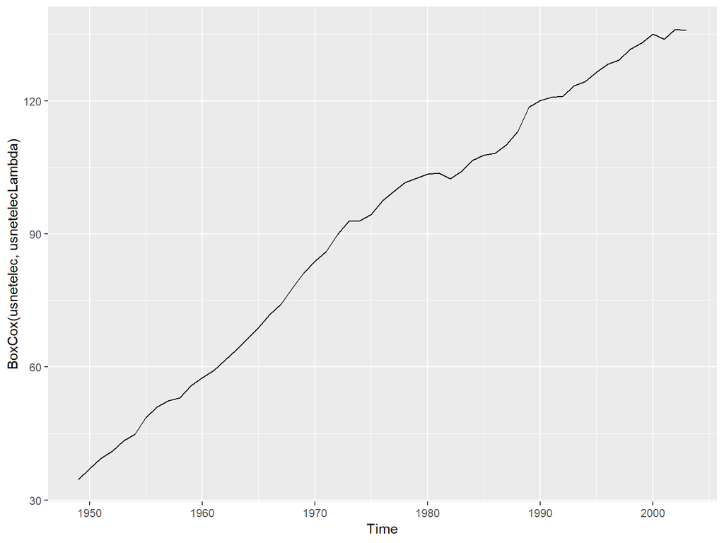

```r
autoplot(BoxCox(usnetelec, usnetelecLambda))
```

```r
# - usgdp
usgdpLambda <- BoxCox.lambda(usgdp)
print(c("Good value of lambda for usgdp: ", usgdpLambda))
```

```
## [1] "Good value of lambda for usgdp: " "0.366352049520934"
```

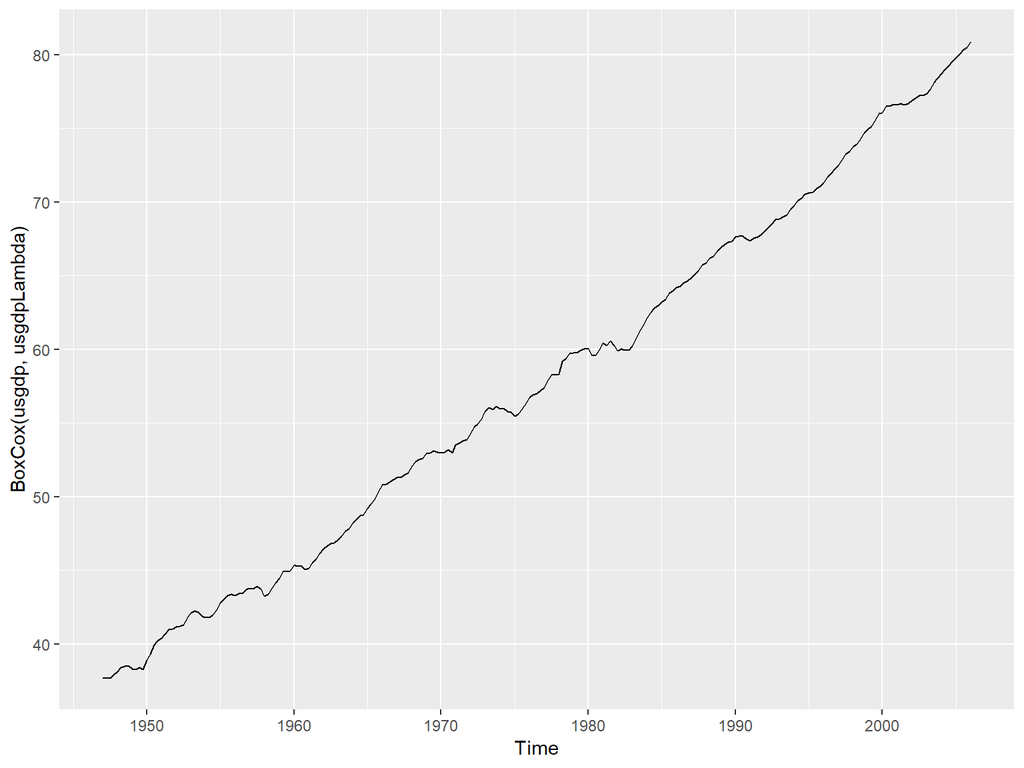

```r
autoplot(BoxCox(usgdp, usgdpLambda))
```

```r
# - mcopper
mcopperLambda <- BoxCox.lambda(mcopper)
print(c("Good value of lambda for mcopper: ", mcopperLambda))
```

```
## [1] "Good value of lambda for mcopper: "
## [2] "0.191904709003829"
```

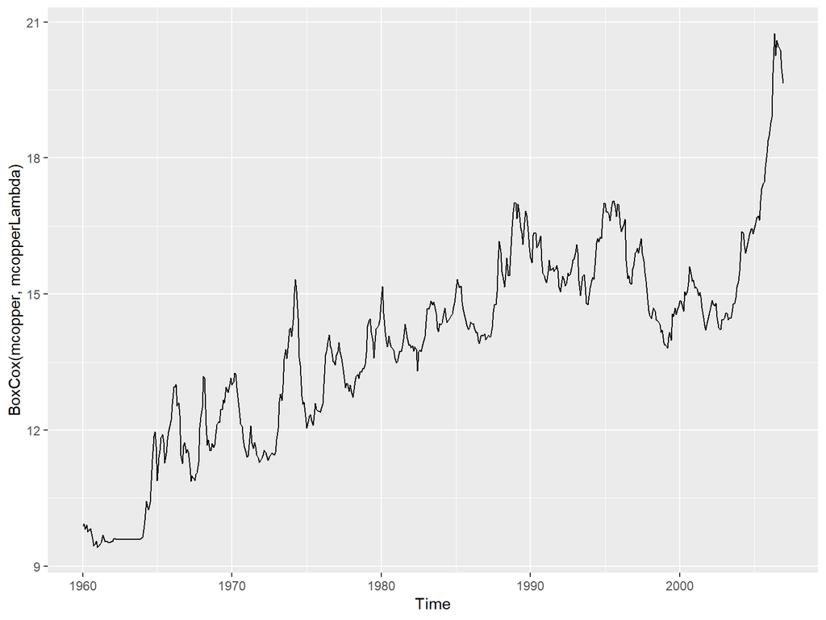

```r
autoplot(BoxCox(mcopper, mcopperLambda))
```

```r
# - enplanements
enplanementsLambda <- BoxCox.lambda(enplanements)
print(c("Good value of lambda for enplanements: ", enplanementsLambda))
```

```
## [1] "Good value of lambda for enplanements: "
## [2] "-0.226946111237065"
```

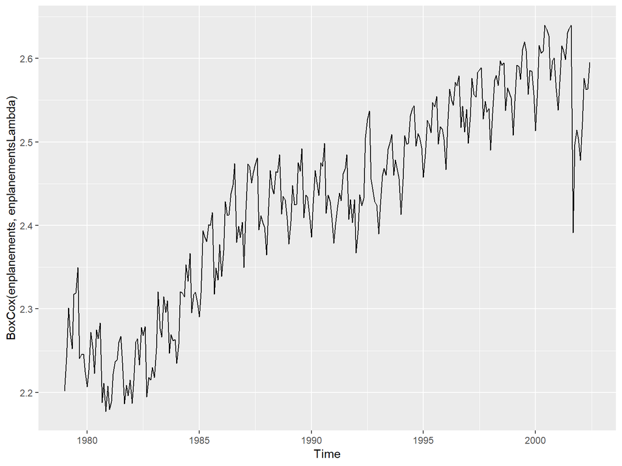

```r
autoplot(BoxCox(enplanements, enplanementsLambda))
```

2. Why is a Box-Cox transformation unhelpful for the cangas data?

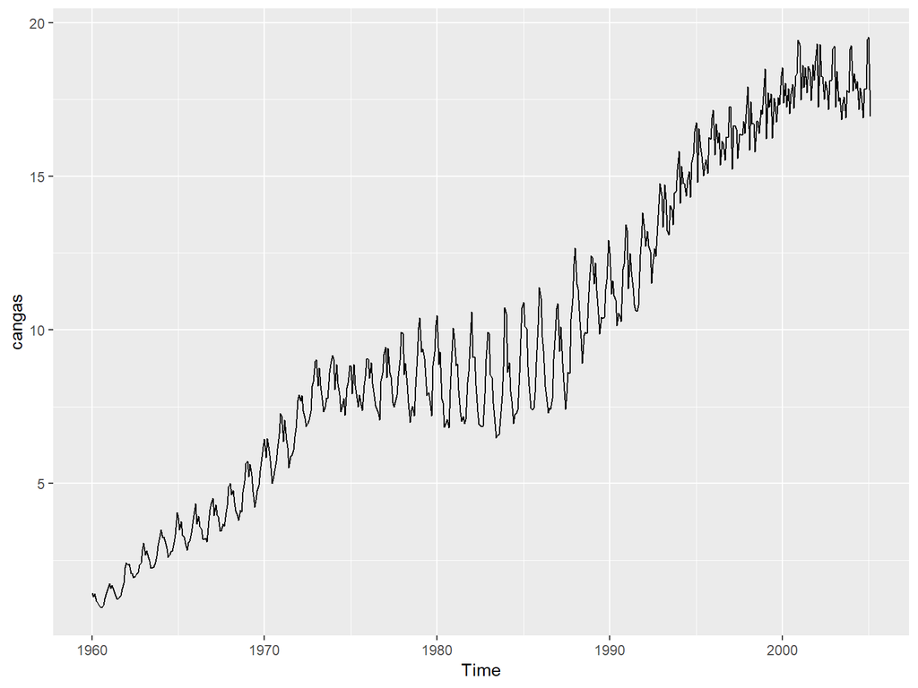

```r
autoplot(cangas)
```

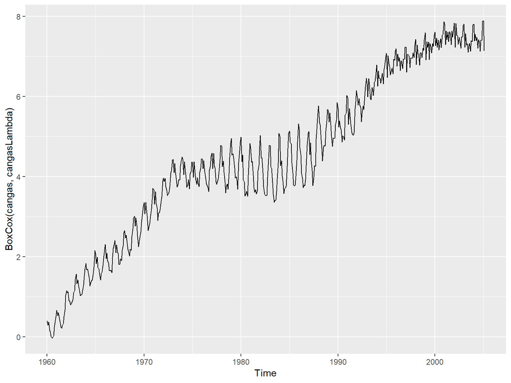

```r
cangasLambda <- BoxCox.lambda(cangas)
autoplot(BoxCox(cangas, cangasLambda))
```

```r
# can see that Box-Cox transformation doesn't yield simpler model
```

3. What Box-Cox transformation would you select for your retail data (from Exercise 3 in Section 2.10)?

```r
retaildata <- xlsx::read.xlsx("retail.xlsx", sheetIndex = 1, startRow = 2)
myts <- ts(retaildata[,"A3349873A"], frequency=12, start=c(1982,4))
retailLambda <- BoxCox.lambda(myts)
print(c("selected lambda:", retailLambda))
```

```
## [1] "selected lambda:"  "0.127636859661548"
```

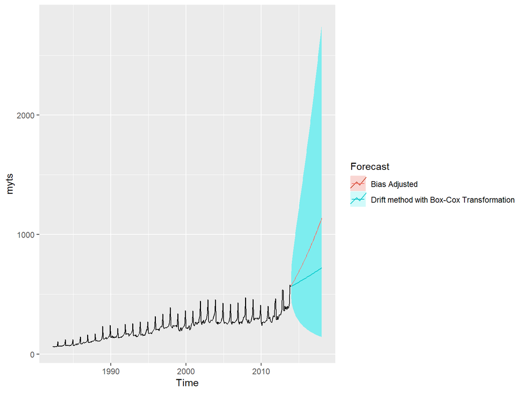

```r
fc_retail <- rwf(myts,
                 drift = TRUE,
                 lambda = retailLambda,
                 h = 50,
                 level = 80)
fc_retail_biasadj <- rwf(myts,
                         drift = TRUE,
                         lambda = retailLambda,
                         h = 50,
                         level = 80,
                         biasadj = TRUE)
autoplot(myts) +
  autolayer(fc_retail, series = "Drift method with Box-Cox Transformation") +
  autolayer(fc_retail_biasadj$mean, series = "Bias Adjusted") +
  guides(colour = guide_legend(title = "Forecast"))
```

```r
# It would be better to choose bias adjusted Box-Cox Transformation with lambda = 0.128
```